# keras_randomly_augmented_images

```python
import os, shutil
```

```python
from google.colab import drive
drive.mount('/content/drive')
```

```python
!rm -rf '/content/cats_vs_dogs_small'
!rm -rf '/content/dogs_cats'
```

```python
!unzip -qq '/content/drive/MyDrive/Colab_Notebooks/SECONDYEAR_TRIMESTER4_Module03_deep-learning-applications/DAY3_APPLICATION_OF_DEEP_LEARNING/dogs_cats.zip'
```

Path to the directory where the original dataset was uncompressed

```python
import pathlib
original_dataset_dir = pathlib.Path("dogs_cats/train")
```

Directory where you’ll store your smaller dataset

```python
base_dir = pathlib.Path("cats_vs_dogs_small")
os.mkdir(base_dir)
```

Directories for the training, validation, and test splits

```python
train_dir = os.path.join(base_dir, 'train')
os.mkdir(train_dir)
validation_dir = os.path.join(base_dir, 'validation')
os.mkdir(validation_dir)
test_dir = os.path.join(base_dir, 'test')
os.mkdir(test_dir)
```

Directory with training cat pictures

```python
train_cats_dir = os.path.join(train_dir, 'cats')
os.mkdir(train_cats_dir)
```

Directory with training dog pictures

```python
train_dogs_dir = os.path.join(train_dir, 'dogs')
os.mkdir(train_dogs_dir)
```

Directory with validation cat pictures

```python
validation_cats_dir = os.path.join(validation_dir, 'cats')
os.mkdir(validation_cats_dir)
```

Directory with validation dog pictures

```python
validation_dogs_dir = os.path.join(validation_dir, 'dogs')
os.mkdir(validation_dogs_dir)
```

Directory with test cat pictures

```python
test_cats_dir = os.path.join(test_dir, 'cats')
os.mkdir(test_cats_dir)
```

Directory with test dog pictures

```python
test_dogs_dir = os.path.join(test_dir, 'dogs')
os.mkdir(test_dogs_dir)
```

Copies the first 1,000 cat images to train_cats_dir

```python
fnames = ['cat.{}.jpg'.format(i) for i in range(1000)]
for fname in fnames:
    src = os.path.join(original_dataset_dir, fname)
    dst = os.path.join(train_cats_dir, fname)
    shutil.copyfile(src, dst)
```

Copies the next 500 cat images to validation_cats_dir

```python
fnames = ['cat.{}.jpg'.format(i) for i in range(1000, 1500)]
for fname in fnames:
    src = os.path.join(original_dataset_dir, fname)
    dst = os.path.join(validation_cats_dir, fname)
    shutil.copyfile(src, dst)
```

Copies the next 500 cat images to test_cats_dir

```python
fnames = ['cat.{}.jpg'.format(i) for i in range(1500, 2000)]
for fname in fnames:
    src = os.path.join(original_dataset_dir, fname)
    dst = os.path.join(test_cats_dir, fname)
    shutil.copyfile(src, dst)
```

Copies the first 1,000 dog images to train_dogs_dir

```python
fnames = ['dog.{}.jpg'.format(i) for i in range(1000)]
for fname in fnames:
    src = os.path.join(original_dataset_dir, fname)
    dst = os.path.join(train_dogs_dir, fname)
    shutil.copyfile(src, dst)
```

the next 500 dog images to validation_dogs_dir

```python
fnames = ['dog.{}.jpg'.format(i) for i in range(1000, 1500)]
for fname in fnames:
    src = os.path.join(original_dataset_dir, fname)
    dst = os.path.join(validation_dogs_dir, fname)
    shutil.copyfile(src, dst)
```

Copies the next 500 dog images to test_dogs_dir

```python
fnames = ['dog.{}.jpg'.format(i) for i in range(1500, 2000)]
for fname in fnames:
    src = os.path.join(original_dataset_dir, fname)
    dst = os.path.join(test_dogs_dir, fname)
    shutil.copyfile(src, dst)
```

```python
import os
from keras.preprocessing import image
from keras.preprocessing.image import ImageDataGenerator
```

Setting up a data augmentation configuration via ImagedataGenerator

```python
datagen = ImageDataGenerator(
rotation_range=40,
width_shift_range=0.2,
height_shift_range=0.2,
shear_range=0.2,
zoom_range=0.2,
horizontal_flip=True,
fill_mode='nearest')
```

list of all cat training image paths

```python
fnames = [os.path.join(train_cats_dir, fname) for fname in os.listdir(train_cats_dir)]
```

Select an image to augment/modify

```python
img_path = fnames[25]
```

list of all cat training image paths

```python
fnames = [os.path.join(train_cats_dir, fname) for fname in os.listdir(train_cats_dir)]
```

Select an image to augment/modify

```python
img_path = fnames[25]
```

reads the image and resizes it

```python
from keras.utils import load_img, img_to_array,array_to_img
```

```python
img = load_img(img_path, target_size=(150, 150))
```

Converts to Numpy array with shape (150,150,3)

```python
x = img_to_array(img)
```

Reshapes it to (1, 150, 150, 3)

```python
x = x.reshape((1,) + x.shape)
```

```python
import matplotlib.pyplot as plt
```

# Generates batches of randomly transformed images. Loops indefinitely,so you need to break the loop at some point!

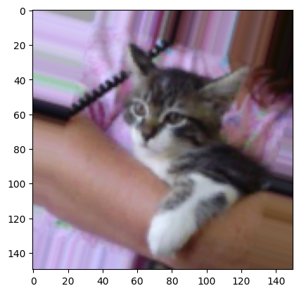

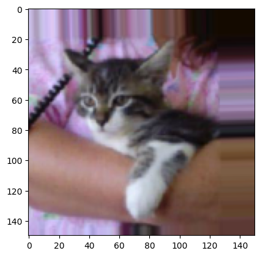

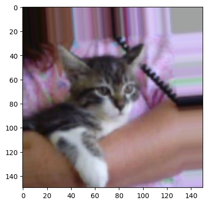

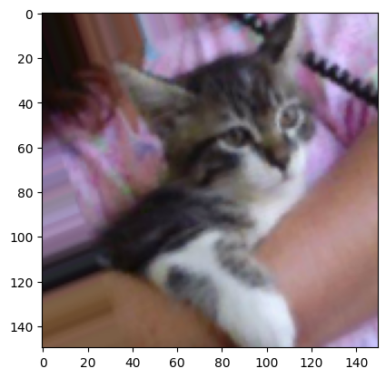

```python
i = 0
for batch in datagen.flow(x, batch_size=1):
    plt.figure(i)
    imgplot = plt.imshow(array_to_img(batch[0]))
    i += 1
    if i % 4 == 0:
        break

    plt.show()
```

```python
!jupyter nbconvert --to html keras_randomly_augmented_images.ipynb
```